# Introduction and importing data

Hi there. Welcome to a little tutorial on how to use all the functions I’ve created.

```r
source("C:/scripts/seahorse.R")
source("C:/scripts/seahorse_misc.R")
```

This will load all of the seahorse scripts that I have written. I’ll go through every function I made, what it does, and why it does that. I’m sure some of these functions can be better optimized as well.

First, we need to load the data. The data comes from NOAA as a NetCDF file. It’s basically a sort of array of data. The source commands above already imported the packages required for looking at the data. We will look at the year 2020.

```r
d2020 = nc_open("hgt.2020.nc")
d2020
```

```
## File hgt.2020.nc (NC_FORMAT_NETCDF4_CLASSIC):
##
##      2 variables (excluding dimension variables):
##         float hgt[lon,lat,level,time]
##             long_name: mean Daily Geopotential height
##             units: m
##             precision: 0
##             least_significant_digit: 0
##             GRIB_id: 7
##             GRIB_name: HGT
##             var_desc: Geopotential height
##             level_desc: Multiple levels
##             statistic: Mean
##             parent_stat: Individual Obs
##             missing_value: -9.96920996838687e+36
##             valid_range: -700
##              valid_range: 35000
##             dataset: NCEP Reanalysis Daily Averages
##             actual_range: -507.25
##              actual_range: 32319
##         double time_bnds[nbnds,time]
##
##      5 dimensions:
##         level  Size:17
##             units: millibar
##             actual_range: 1000
##              actual_range: 10
##             long_name: Level
##             positive: down
##             GRIB_id: 100
##             GRIB_name: hPa
##             axis: Z
##         lat  Size:73
##             units: degrees_north
##             actual_range: 90
##              actual_range: -90
##             long_name: Latitude
##             standard_name: latitude
##             axis: Y
##         lon  Size:144
```

[output cut: 14 more lines]

```
##             actual_range: 1928472
##              actual_range: 1937232
##         nbnds  Size:2
## [1] "vobjtovarid4: **** WARNING **** I was asked to get a varid for dimension named nbnds BUT this dimension HAS NO DIMVAR! Code will probably fail at this point"
##
##     7 global attributes:
##         Conventions: COARDS
##         title: mean daily NMC reanalysis (2014)
##         history: created 2013/12 by Hoop (netCDF2.3)
##         description: Data is from NMC initialized reanalysis
## (4x/day).  It consists of most variables interpolated to
## pressure surfaces from model (sigma) surfaces.
##         platform: Model
##         dataset_title: NCEP-NCAR Reanalysis 1
##         References: http://www.psl.noaa.gov/data/gridded/data.ncep.reanalysis.html
```

As we can see, looking at the variable created gives us a giant paragraph of information. We need to know a few things:

- Variable name (which is hgt)
- Dimensions of the variable (lon, lat, level, time)

We will go ahead and grab hgt like this:

```r
hgt2020 = ncvar_get(d2020,"hgt")
```

Now the variable hgt2020 will be a 4-dimensional matrix with the above dimensions. To see the range of those dimensions, we can use the same command on the dimension names.

```r
lat = ncvar_get(d2020,"lat")
lon = ncvar_get(d2020,"lon")
lvl = ncvar_get(d2020,"level")
tm = ncvar_get(d2020,"time")
# Getting all the variable information

lvl
```

```
##  [1] 1000  925  850  700  600  500  400  300  250  200  150  100   70   50   30
## [16]   20   10
```

The output above is for the level variable. These are the mb heights that we look into. Most of the years from NOAA use the same range of 1000 -> 10, but some years are missing some levels for some unknown reason. You can’t just import this for every year and automatically choose which value. I don’t know why it is that way but it is what it is.

The other 3 variables that I didn’t show the output for (since it’s just a big output of numbers) are as follows:

```r
y2020 = hgt2020[,20:5,6,]
```

This gives us a 3-dimensional matrix which represents a slice of the atmosphere at 500mb over 366 days, since 2020 is a leap year.

# Commands inside seahorse.R

Now we can use some commands. I’ll go function by function. Some are extremely simple and some are not.

## fix_series(d)

Since we are fixing the latitudes when we look at them, we get a simple curve. For example:

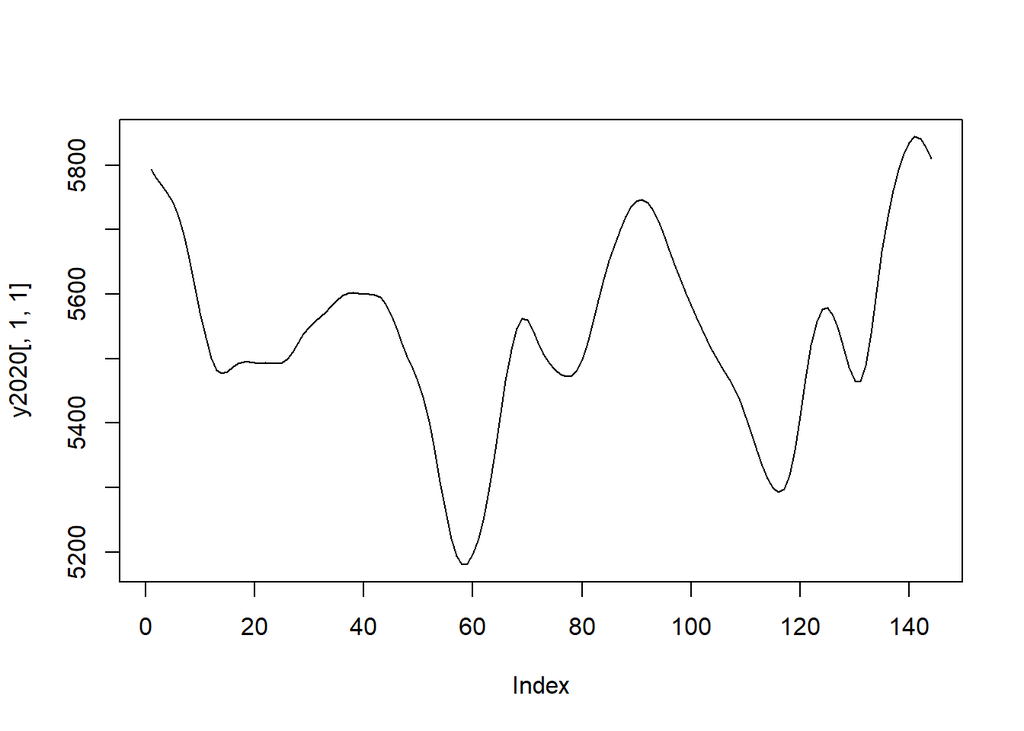

```r
plot(y2020[,1,1],type='l')
```

What we don’t want to do is to double count features if they go from the ends to each other. My way of taking care of this problem was to move the minimum to the border. Adam coded a union find algorithm that does the same thing but is probably more efficient as we don’t need the TDA package with his.

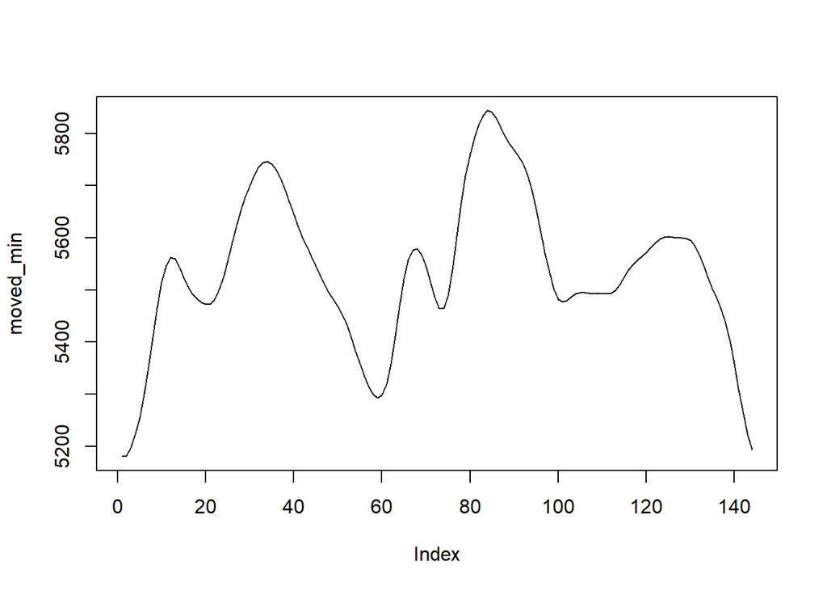

```r
moved_min = fix_series(y2020[,1,1])
plot(moved_min,type='l')
```

Now we can see that the minimums are on the borders, so there is no chance that we will double count any features.

## count_gd(d,ln,l)

This function performs a morse filtration on a single height and reports the number of features. The input **d** is a fixed latitude on a single day. For example, y2020[,1,1] would be the first day looking at the first latitude that is chosen. The input **ln** is the height we are looking at. The input **l** is currently not working correctly so should be set to zero.

```r
count_gd(y2020[,1,1],ln=5700,l=0)
```

```
## [1] 2
```

```r
# This is checking the first day, first latitude, at 5700 geopotential height and returning
# the number of features detected
```

This function is not super useful by itself, but is called for other functions. This can likely be optimized a lot since this is one of the first things I made. Adam’s function is a single function, and mine chains them together which I’m sure is computationally bad.

## count_gd_heights(d,day,lts,l,omax,nheight)

This function performs count_gd over many heights. This takes the entire 3-D matrix as an input, and uses parameters **day** and **lts** to slice the matrix itself. The input **omax** is used for when creating the horseZ plots later and should be ignored. The input **nheights** is the number of heights to “slice” up. The default is 100.

```r
count_gd_heights(y2020,1,1,l=0)
```

```
##   [1] 0 0 0 0 0 0 0 0 0 0 0 0 0 0 0 0 0 0 0 0 0 0 0 0 0 0 0 0 0 0 0 0 0 0 0 0 0
##  [38] 0 0 0 0 0 0 0 0 1 1 1 1 1 1 1 1 1 2 2 2 2 2 2 2 2 2 2 2 2 2 2 3 5 5 5 5 5
##  [75] 5 5 4 4 3 3 2 2 2 2 2 2 2 2 2 2 2 2 1 1 1 1 1 1 1 0
```

```r
# This is checking the first day, first latitude, at 100 different geopotential heights
# and returning the number of features detected at each as a series
```

## count_gd_day(d,day,plot,title,l,summary,omax,nheight)

This is the function that will plot the seahorse. It will take the whole 3-D matrix, and a particular day. You can set **plot** to either T/F if you want the plot to show up. We can change **title** to display the title of the plot. Summary overlays some summary stats like mean, median, etc…

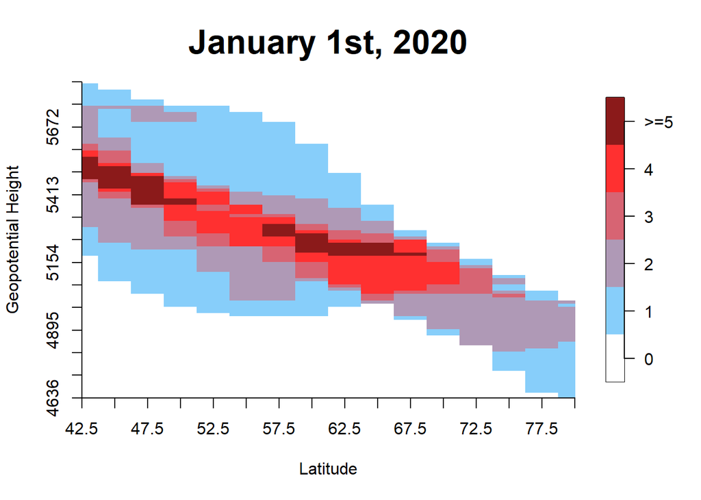

```r
count_gd_day(y2020, 1, plot=T, title = "January 1st, 2020", l=0)
```

```r
# This is checking the first day, every latitude, at 100 different geopotential heights
# and plotting them with a color depending on the number of features detected
```

Keep in mind that the axis currently only works for our particular set of latitudes and longitudes. That means that the x-axis will always read 42.5N to 80N, regardless of what you’re actually looking at. I would like to fix this at some point, but if I don’t then it shouldn’t be too hard for someone else to fix. As an example, this is how the plot looks if we look at ALL latitudes and longitudes. It actually looks pretty neat.

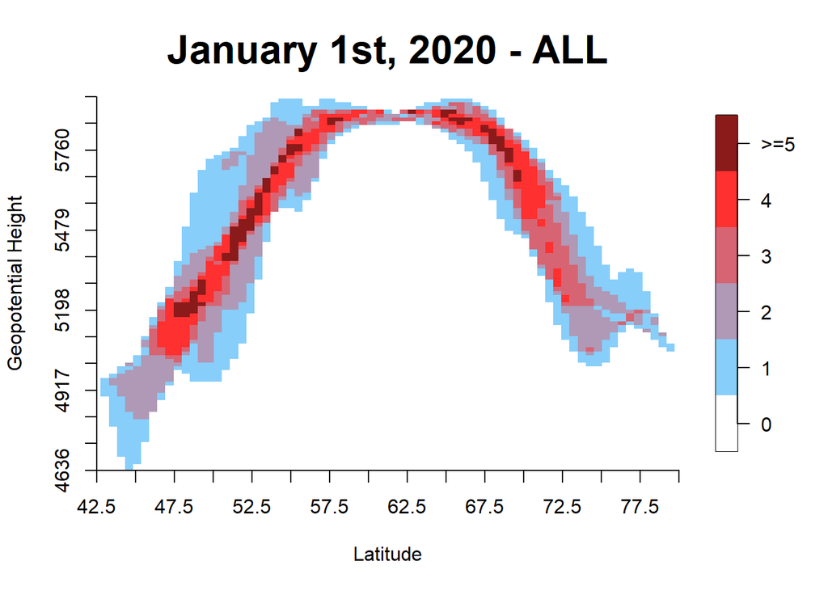

```r
testyr = hgt2020[,,6,]
count_gd_day(testyr, 1, plot=T, title = "January 1st, 2020 - ALL", l=0)
```

## build_comp(daycomp,year_comp,days_back,years_back,l)

This is the big boy function that creates, basically, an array that hosts a distribution of the features detected in each possible latitude/longitude combination. This one takes a bit more explanation.

Builds a baseline to compare against. Each pixel will have (days_back+1) by years_back number of samples. For example, days_back=30 and years_back=30 would contain 930 samples per pixel. If your matrix is 100by100, then you would have 10,000 pixels, each with 930 samples, so this is a relatively large process for less powerful laptops like mine :(. It takes inputs daycomp(the day we “start at” in the year, 1-365), year_comp(the year we “start at”, ex 2010 or 2015), days_back(the number of days to step backwards from daycomp. If daycomp = 31 and days_back=30, we do days 31-1), years_back(the number of years to step backwards from year_comp),l(the smallest lifetime to be considered a feature)

Now, there is a requirement for the names of variables. The matrix that has data for the year 2020, for example, should be named y2020. Therefore, ALL years must be named yXXXX where XXXX is the year (y2020, y1990, etc…). The function uses these to go through everything.

Currently, you must manually set all of this. It should be decently easy to automate it to create baselines (even for accounting for leap years). Thus, you have to create a baseline for each month and then smush them together. For instance:

```r
# Example of how we would build the reference database thing
jan30_0 = build_comp(daycomp=31,year_comp=2010,days_back=30,years_back=29,l=0)
data30_0 = list(jan30_0,feb30_0,...)
```

This would look at every January in 1980 - 2010 and create a reference for January ONLY. As I currently do not have 40+ of these loaded into my R-session, and it takes a decently long time to compute, we will be like Martha Stewart and use a database that I have prepared earlier.

```r
# This file can be found on the github
# the _0 part indicates we used l=0 to generate this
load(file="bymonth30_0.RData")
```

This comparison data has multiple parts inside it that we can look at or plot or just have general fun with.

To look at a particular month, we use bymonth30_0[[1]] for January, bymonth30_0[[2]] for February, and in general bymonth30_0[[k]] where k is the number of the month. In addition, there are different parts of each.

- $Raw -> The raw data that is built.
- $Mean -> The means of each latitude/longitude intersection.
- $SD -> The standard deviations of each.

## horsieZ(d,daycomp,mtx,l,plotting,title)

The neat plot. It takes inputs **d** which is a 3-D matrix of a particular year, **daycomp** which is the day we want to compare (out of 365/366), **mtx** which is the matrix we compare it to, **plotting** which is if we should plot it or not, and **title** which is the title of the plot.

For example, let’s compare January 1st, 2020 to all of the data from January.

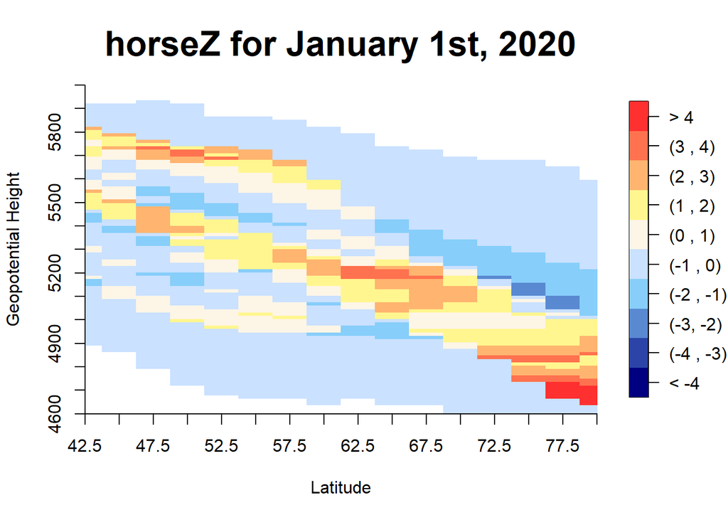

```r
horsieZ(y2020,1,mtx=bymonth30_0[[1]],l=0,plotting=T,title="horseZ for January 1st, 2020")
```